# Time Series Visualization

# Plotting Change : Time Series

Any metric that is measured over regular time intervals forms a time series. Weather data, Stock prices, Industry forecasts, are some of examples of time series.

**How to create a Time Series in R ?**

Upon importing your data into R, use the `ts()` function as follows:

```r
# freq 12 => Monthly data.
ts(1:10, frequency = 12, start = 1990)
```

```
##      Jan Feb Mar Apr May Jun Jul Aug Sep Oct
## 1990   1   2   3   4   5   6   7   8   9  10
```

The `inputData` is ideally a numeric vector of the class `numeric` or `integer`.

```r
# frequency 4 => Quarterly Data
ts(inputData, frequency = 4, start = c(1959, 2))
# Yearly Data
ts(inputData, start=c(2009), end=c(2014), frequency=1)
```

## Time Series Plot From a Data Frame

Using `geom_line()`, a time series (or line chart) can be drawn from a `data.frame`.

```r
library(tidyverse)
```

Consider the `economics` dataset, a US economics time series dataset that was produced from US economic time series data available from https://fred.stlouisfed.org/ `economics` is in “wide” format, `economics_long` is in “long” format. Some of the variables included in this dataset are:

| Variable | Description |
| --- | --- |
| `date` | Month of data collection |
| `psavert` | personal savings rate |
| `pce` | personal consumption expenditures, in billions of dollars |
| `pop` | total population, in thousands |

```r
# Compute % Returns
economics$returns_perc <- c(0, diff(economics$psavert)/economics$psavert[-length(economics$psavert)])
```

The X axis breaks are *generated by default*. In the below example, the breaks are formed once every 10 years.

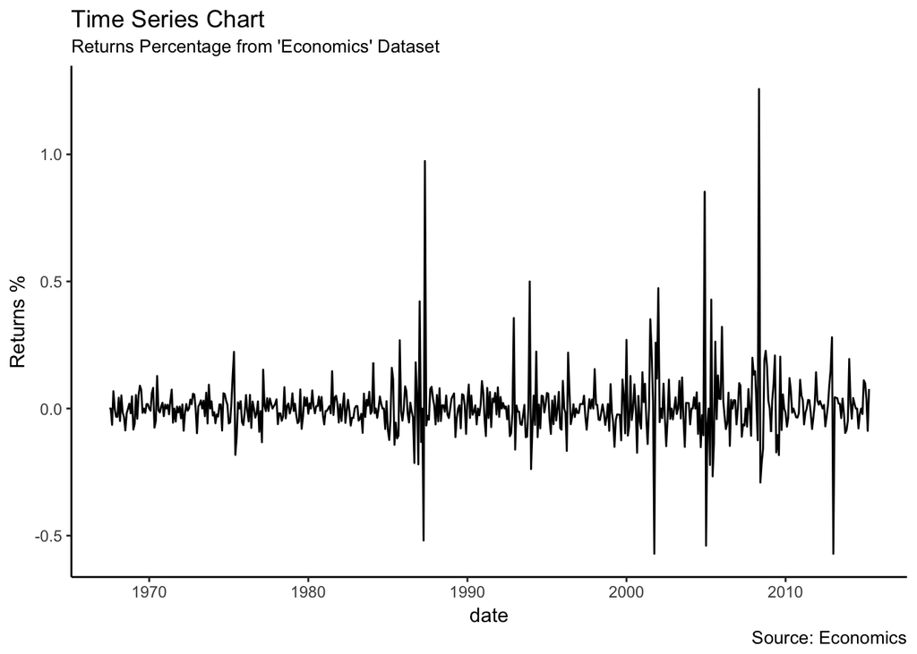

```r
library(ggplot2)
theme_set(theme_classic())

# Compute % Returns
economics$returns_perc <- c(0, diff(economics$psavert)/economics$psavert[-length(economics$psavert)])

# Allow Default X Axis Labels
ggplot(economics, aes(x=date)) +
  geom_line(aes(y=returns_perc)) +
  labs(title="Time Series Chart",
       subtitle="Returns Percentage from 'Economics' Dataset",
       caption="Source: Economics",
       y="Returns %")
```

## Time Series Plot For a Monthly Time Series

`month.abb` is the three-letter abbreviations for the English month names.

If you want to set your own time intervals (breaks) in X axis, you need to set the breaks and labels using `scale_x_date()`.

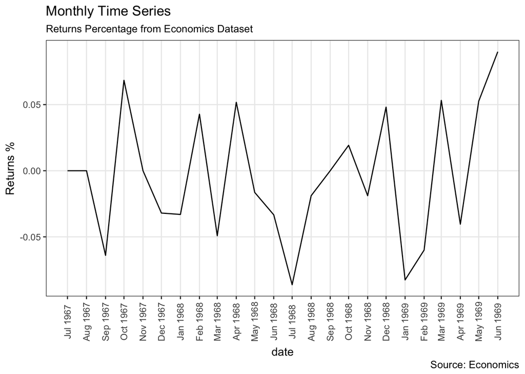

```r
library(ggplot2)
library(lubridate)
theme_set(theme_bw())

economics_m <- economics[1:24, ]

# labels and breaks for X axis text
lbls <- paste0(month.abb[month(economics_m$date)], " ", lubridate::year(economics_m$date))
brks <- economics_m$date

# plot
ggplot(economics_m, aes(x=date)) +
  geom_line(aes(y=returns_perc)) +
  labs(title="Monthly Time Series",
       subtitle="Returns Percentage from Economics Dataset",
       caption="Source: Economics",
       y="Returns %") +  # title and caption
  scale_x_date(labels = lbls,
               breaks = brks) +  # change to monthly ticks and labels
  theme(axis.text.x = element_text(angle = 90, vjust=0.5),  # rotate x axis text
        panel.grid.minor = element_blank())  # turn off minor grid
```

# Interactive Time Series Visualization with `dygraphs`

The `dygraphs` package is an R interface to the `dygraphs` JavaScript charting library. It provides rich facilities for charting time-series data in R, including:

- Automatically plots `xts` time series objects (or any object convertible to `xts`).
- Highly configurable axis and series display (including optional second Y-axis).
- Rich interactive features including zoom/pan and series/point highlighting.
- Various graph overlays including shaded regions, event lines, and point annotations.

## Instalation

Install and load the library

```r
#install.packages("dygraphs")
library(dygraphs)
```

## Example Data : `mdeaths` and `fdeaths`

Here’s a simple dygraph created from a multiple time series object. Consider the Monthly Deaths from Lung Diseases in the UK dataset, that includes three time series giving the monthly deaths from bronchitis, emphysema and asthma in the UK, 1974–1979:

- both sexes (`ldeaths`),
- males (`mdeaths`). and
- females (`fdeaths`).

```r
# create dataset using cbind() function
lungDeaths <- cbind(mdeaths, fdeaths)
# Create dynamic graph
dygraph(lungDeaths)
```

[interactive chart not shown]

As your *mouse moves over* the series individual values are displayed. You can also *select regions* of the graph to *zoom into* (double-click *zooms out*)

You can customize dygraphs by **piping** additional commands onto the original dygraph object. Here we pipe a `dyRangeSelector` onto our original graph:

```r
# Load the tidyverse package (to use pipes and for data wrangling)
library(tidyverse)
# create dataset using cbind() function
lungDeaths <- cbind(mdeaths, fdeaths)

# Create dynamic graph with range selector
dygraph(lungDeaths) %>%
  dySeries("mdeaths", label = "Male") %>%
  dySeries("fdeaths", label = "Female") %>%
  dyOptions(stackedGraph = TRUE) %>%
  dyRangeSelector(height = 20)
```

[interactive chart not shown]

This example uses the `%>%` (or “pipe”) operator from the `magrittr` package to compose the dygraph with the range selector. You use a similar syntax to customize axes, series, and other options.

## Point Display

You can include display of the individual points in a series as well as customize the size of the points:

```r
dygraph(ldeaths, main = "Deaths from Lung Disease (UK)") %>%
  dyOptions(drawPoints = TRUE, pointSize = 2)
```

[interactive chart not shown]

## Highlighting

When users hover their mouse over series and points on the graph a highlight effect appears on the surface of the graph. You can use the `dyHighlight` function to customize how the highlighting appears.

```r
dygraph(lungDeaths, main = "Deaths from Lung Disease (UK)") %>%
  dyHighlight(highlightSeriesOpts = list(strokeWidth = 3))
```

[interactive chart not shown]

## Events and Limits

Event lines are a useful way to note points within a time series where *noteworthy events* occurred. Let us use the `presidents` dataset that contains the (approximately) quarterly approval rating for the President of the United States from the first quarter of 1945 to the last quarter of 1974.

```r
str(presidents)
```

```
##  Time-Series [1:120] from 1945 to 1975: NA 87 82 75 63 50 43 32 35 60 ...
```

As an example, in the following graph we overlay the dates which saw the first deployment of US combat troops to Korea and Vietnam over a plot of US presidential approval ratings:

```r
dygraph(presidents, main = "Quarterly Presidential Approval Ratings") %>%
  dyAxis("y", valueRange = c(0, 100)) %>%
  dyEvent("1950-6-30", "Korea", labelLoc = "bottom") %>%
  dyEvent("1965-2-09", "Vietnam", labelLoc = "bottom")
```

[interactive chart not shown]

Note that we specify that our event labels go at the bottom of the graph so they do not interfere with the legend, and set the y-axis `valueRange` to ensure that there is adequate room at the bottom for the labels.

### References

[dygraphs for R](https://rstudio.github.io/dygraphs/index.html)